# Data Scoping: Job Search Effort/Behaviour

Ebba Mark

2024-11-28

# Overview

The following document summarises current progress on identifying a data source to inform our job search behaviour. I think the two promising avenues are the:

1.**2018/2022 Bureau of Labor Statistics Supplement to the Current Population Survey** which asks detailed questions about job search, application effort, and unemployment duration to those who did not opt in to unemployment insurance/compensation.  
2. **Survey on Consumer Expectations**: Which is a “nationallly representative” survey with a Job Search Supplement conducted from 2014-2021.

I provide some preliminary detail on each of these options below including sample size.

## Current Population Survey - 2018 Supplement - Summarised

This 2020 [“Beyond the Numbers” issue](https://www.bls.gov/opub/btn/volume-9/how-do-jobseekers-search-for-jobs.htm#_edn5) distills insights from a 2018 Supplement to the Current Population Survey. The below plots show the highlights relevant to our decision-making on the job search process. In nearly all cases, the results are “binned” into intervals (ie. number of people sending 81 or more applications or unemployment duration of between 5 and 14 weeks) which means that any line plots (or linear interpretation of the bar graph) should be done carefully. Preliminary results using the raw data are found in the next section.

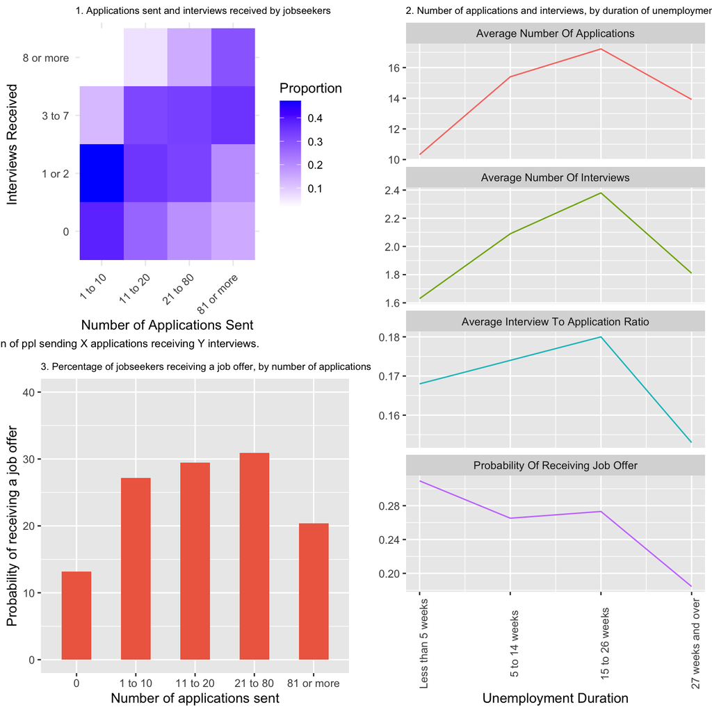

## Current Population Survey - 2018 & 2022 Supplement - Raw Data

It turns out that the 2018 supplement was also run in 2022, giving us two sets of years to compare (including pre- and post-Covid). The below looks at the [raw data](https://www.census.gov/data/datasets/time-series/demo/cps/cps-supp_cps-repwgt/cps-unemployment.2022.html#list-tab-1269561637) that underlies the plotting in the previous section, plus the additional data from 2022. Below find a preliminary scatter plot of applications sent versus unemployment duration. Each individual is asked how many applications they sent in the last two months (two-month periods are indicated by the grey gridlines, for reference). This feels like a promising dataset to me - I think with more careful use of this data this we could approach some more “rigorous” behavioral parameters than simply drawing from the above summary values as calculated by the BLS. This does NOT include data in on the job search. SCE does.

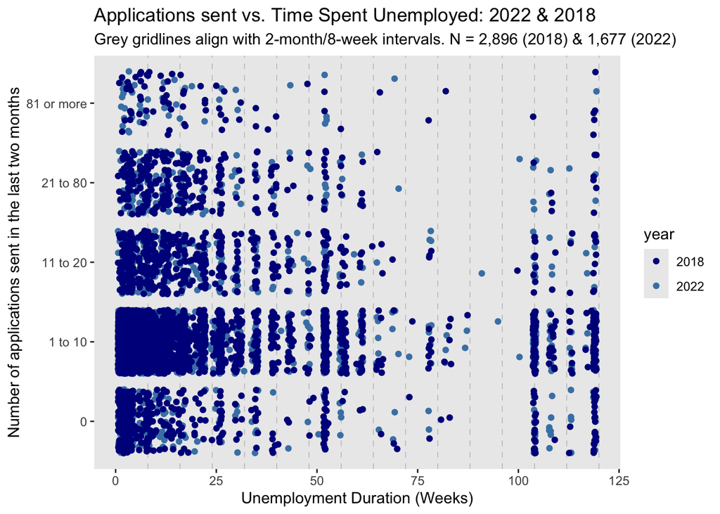

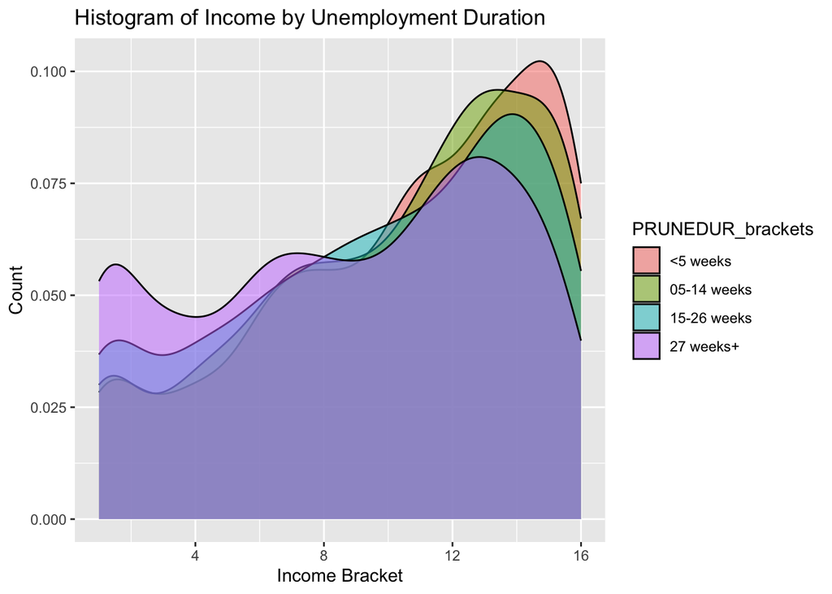

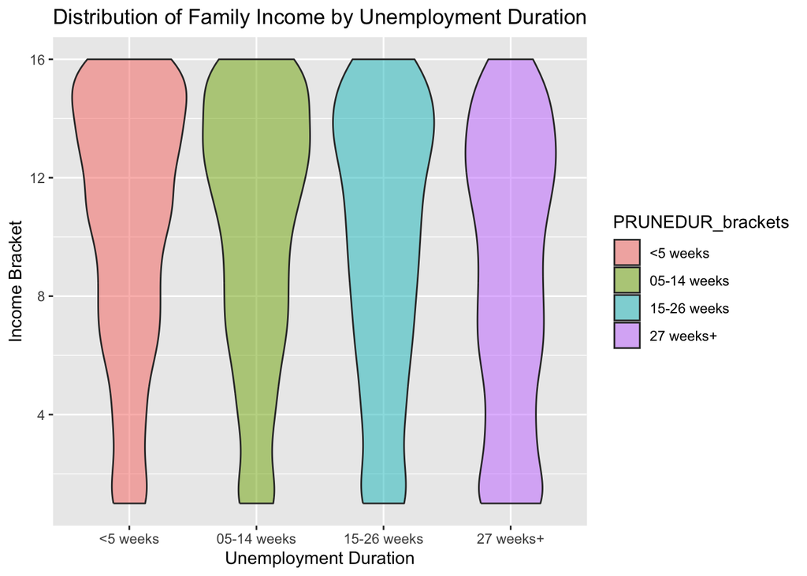

| x |
| --- |
| 1 LESS THAN $5,000 |
| 2 5,000 TO 7,499 |
| 3 7,500 TO 9,999 |
| 4 10,000 TO 12,499 |
| 5 12,500 TO 14,999 |
| 6 15,000 TO 19,999 |
| 7 20,000 TO 24,999 |
| 8 25,000 TO 29,999 |
| 9 30,000 TO 34,999 |
| 10 35,000 TO 39,999 |
| 11 40,000 TO 49,999 |
| 12 50,000 TO 59,999 |
| 13 60,000 TO 74,999 |
| 14 75,000 TO 99,999 |
| 15 100,000 TO 149,999 |
| 16 150,000 OR MORE |

## Survey on Consumer Expectations - Job Search Supplement

| Year | N Unemployed | N Unemp & Searching |
| --- | --- | --- |
| 2014 | 383 | 70 |
| 2015 | 321 | 44 |
| 2016 | 339 | 46 |
| 2017 | 350 | 38 |
| 2018 | 354 | 41 |
| 2019 | 343 | 32 |
| 2020 | 304 | 45 |
| 2021 | 330 | 50 |

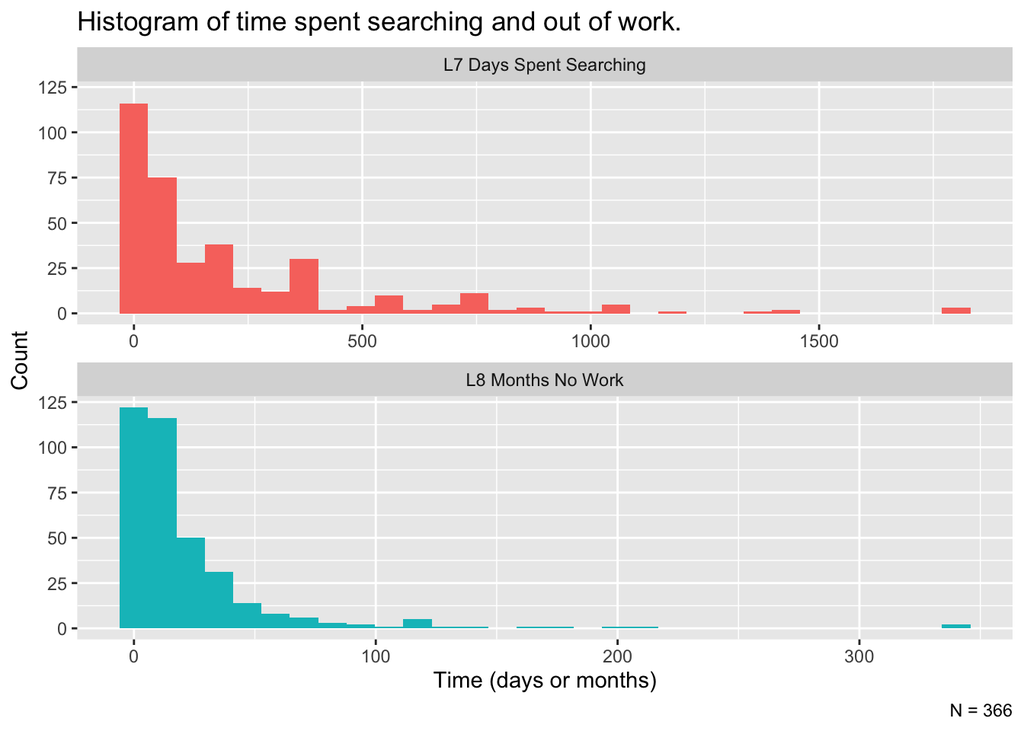

[figure not shown]

### On the job search

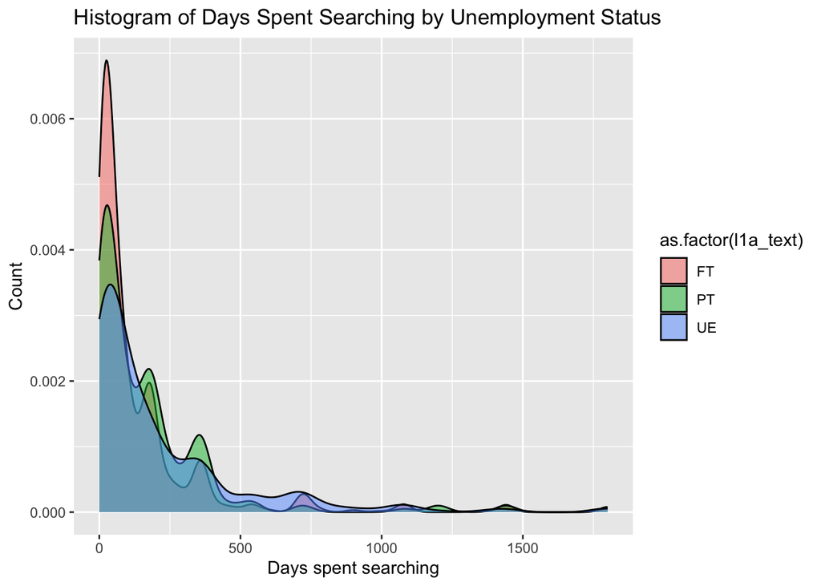

## American Time Use Survey

The American Time Use Survey gives no indication of time spent in unemployment. It shows how much time is spent searching but does not link to time spent in unemployment. Therefore, I prioritised the datasets above. [Krueger & Mueller 2010](https://www.sciencedirect.com/science/article/abs/pii/S0047272709001625) impute duration spent unemployed from teh ATUS in the following way which could be worth considering.

“Unfortunately, the ATUS interview does not collect information on unemployment duration. Consequently, we derive unemployment duration by taking the unemployment duration reported in the last CPS interview and adding the number of weeks that elapsed between the CPS interview and the ATUS interview. Eighty-six percent of the ATUS interviews were conducted within 3 months of the last CPS interview. For those who were not unemployed at the time of the CPS interview, we impute duration of unemployment by taking half the number of weeks between the CPS and the ATUS interviews. We do not show the weekly LOWESS plot for 13 weeks or less, but simply report the average time allocated to search, as the imputed unemployment duration are quite noisy for those who become unemployed after their last CPS interview.”

## Occupational Restructuring